# R Notebook

# Weekend Homework - Week 06 - Statistics

## Background

You work for an animal conservation organisation and are looking to do some investigating into some of the animals to provide evidence for some projects you are looking to run.

```r
library(skimr)
```

## 1.1 Hypothesis testing

### Question 1

Explore the dataset and familiarise yourself with it.

| name | genus | vore | order | conservation | sleep_total | sleep_rem | sleep_cycle | awake | brainwt | bodywt |
| --- | --- | --- | --- | --- | --- | --- | --- | --- | --- | --- |
| Cheetah | Acinonyx | carni | Carnivora | lc | 12.1 | NA | NA | 11.9 | NA | 50.000 |
| Owl monkey | Aotus | omni | Primates | NA | 17.0 | 1.8 | NA | 7.0 | 0.01550 | 0.480 |
| Mountain beaver | Aplodontia | herbi | Rodentia | nt | 14.4 | 2.4 | NA | 9.6 | NA | 1.350 |
| Greater short-tailed shrew | Blarina | omni | Soricomorpha | lc | 14.9 | 2.3 | 0.1333333 | 9.1 | 0.00029 | 0.019 |
| Cow | Bos | herbi | Artiodactyla | domesticated | 4.0 | 0.7 | 0.6666667 | 20.0 | 0.42300 | 600.000 |
| Three-toed sloth | Bradypus | herbi | Pilosa | NA | 14.4 | 2.2 | 0.7666667 | 9.6 | NA | 3.850 |

### Question 2 -

Jabberwockies sleep for around 7 hours a night, on average. Perform an appropriate statistical test to determine whether the mean sleep_total in the sampled population of animal types differs from the typical value for jabberwockies

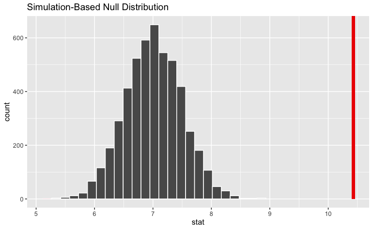

| p_value |
| --- |
| 0 |

p_value = 0.001 (is shown as 0, but cannot be 0).

**Conclusion:** We reject H0, as P-value < α = 0.001 < 0.05 The average total sleep of all animals is significantly different from the average sleep of jabberwockies

### Question 3 -

Perform an appropriate statistical test to determine whether omnivores sleep for significantly longer than herbivores, on average.

| p_value |
| --- |
| 0.131 |

6. conclusion

p-value > α, 0.131 > 0.05 We cannot reject H0, there is no significant difference in total sleep between herbivores and omnivores

### Question 4 -

Perform an appropriate statistical test to determine whether the proportion of domesticated animal types in the population of animal types is greater than 5%.

-> we need to do a one-sample proportion hypothesis test

| p_value |
| --- |
| 0.0104 |

Conclusion: pvalue < α 0.01 < 0.05 We therefore reject H0 The proportion of domestic animals is significantly higher than 5%

## 1.2 Defining the hypothesis

### Question 1 -

*-> Test to use:* One-sample independent hypothesis test for proportion

*-> Defining H0 and H1:* **H0** = The proportion of people heard of shop is equal to 40% = π(heard_of_shop) = 0.4

**H1** = The proportion of people heard of shop is more than 40% = π(heard_of_shop) > 0.4

*-> method to generate null distribution:* = draw

### Question 2 -

*-> Test to use:* two-sample paired hypothesis test for proportions

(paired because the users, are using the website before and than will either see a edited or un-edited version). Proportions, because you want to compare the proportion of clicks on the banner for each group.)

*-> Defining H0 and H1:* **H0** = The proportion of people in group A clicking on the banner is equal to the proportion of people in group B clicking on the banner = π(group_A_clicking_on_banner) = π(group_B_clicking_on_banner)

**H1** = The proportion of people in group A clicking on the banner is smaller than the proportion of people in group B clicking on the banner = π(group_A_clicking_on_banner) < π(group_B_clicking_on_banner)

*-> method to generate null distribution:* = permutation

### Question 3 -

*-> Test to use:* one-sample mean hypothesis test

*-> Defining H0 and H1:* **H0** = The width of the produces car part is equal to the standard 145mm = µ(part_width) = 145

**H1** = The width of the produces car part is unequal to the standard 145mm = µ(part_width) ≠ 145

*-> method to generate null distribution:* = bootstrap

## 1.3 Interpreting the results

### Question 1

Coffee shop problem. Significance level: 0.05, calculated p-value: 0.07

Conclusion: p-value > 0.05 We fail to reject H0, we have failed to prove that the proportion of people heard of the coffee shop is unequal to 40%.

### Question 2

Website company problem. Significance level: 0.01, p-value: 0.006

Conclusion: p-value < 0.01 We can therefore reject H0, the proportion of people in group A clicking on the banner is significantly smaller than the proportion of people in group B clicking on the banner.

### Question 3

Manufacturing company problem. Significance level: 0.05, p-value: 0.55

Conclusion: p-value > 0.05 We therefore fail to reject H0, the average width of the produced car part is statistically significantly equal to the standard 145mm.